# Structural Roots of Electoral Fragmentation in Romania: A County-Level Analysis of the 2024–2025 Electoral Cycle

MSc Data Science — Quantitative Political Analysis

Andrei Manoloiu

mai 2026

# Abstract

Romania’s 2024–2025 electoral cycle produced a historic fragmentation of parliamentary vote shares alongside the unexpected rise of nationalist-populist candidates. Using official county-level (*județ*) data for all 42 NUTS-3 units, this paper examines three structural mechanisms linking socio-economic geography to electoral outcomes.

First, we derive a five-cluster typology of Romanian counties through Ward hierarchical clustering on 34 structural features reduced via PCA, and validate it against held-out electoral data. Second, we model the joint composition of parliamentary vote shares using Dirichlet regression, showing that deindustrialisation is the dominant cross-party structural predictor while ethnic composition is the sharpest single-party predictor. Third, we quantify the persistence of a nationalist-populist electoral bloc across the 2024–2025 presidential elections using the Frisch-Waugh-Lovell partial correlation framework with sensitivity analysis.

**Keywords:** Romanian elections, Dirichlet regression, electoral geography, deindustrialisation, compositional data analysis, voter typology.

# Introduction

Romania’s December 2024 parliamentary elections and the subsequent 2025 presidential re-run produced an electoral landscape with no precedent in the post-communist period. The radical-right Alliance for Romania’s Unity (AUR) consolidated its position as the second largest parliamentary force; the nationalist SOS România entered parliament for the first time; and Călin Georgescu’s first-round presidential result — subsequently annulled by the Constitutional Court — demonstrated the mobilisation potential of diffuse online-networked populism outside traditional party structures.

Two questions motivate this study. *What structural conditions differentiate counties that produced high nationalist-populist vote shares from those that did not?* And *to what extent does county-level support for Georgescu in November 2024 predict support for George Simion in May 2025, net of shared structural characteristics?*

We approach both questions with compositional and partial-correlation methods that respect the constrained nature of vote shares and guard against confounding through systematic covariate adjustment.

# Data and Measurement

## Electoral outcomes

Parliamentary vote shares for the December 2024 elections were obtained from the Permanent Electoral Authority (AEP). We model eight compositional outcomes: AUR, PSD, PNL, USR, UDMR, SOS, POT, and a residual *Other* category. All shares were reweighted to sum to exactly one after excluding invalid ballots. Presidential first-round results for Călin Georgescu (November 2024) and George Simion (May 2025) were sourced from the same authority.

## Structural predictors

County-level structural characteristics were assembled from three sources:

- **Eurostat NUTS-3 database** (2022 reference year): GDP per capita, unemployment rate, household income (PPS), long-term unemployment rate, industry GVA share, early school leaving, tertiary education, net and temporary emigration rates, infrastructure density, and religious/ethnic composition from the 2021 census.
- **Romanian National Statistics Institute (INS)**: population density, age structure, employment by sector, healthcare and school unit density, urbanisation, and household size.
- **Derived indices**: The *grievance index* ($\overline{z}$ of unemployment, poverty risk, early school leaving, and long-term unemployment, reversed for income), the *modernity index* ($\overline{z}$ of tertiary education, internet use, and GDP per capita), and the *deindustrialisation index* (industry GVA share 2010 − industry GVA share 2022, clipped at zero).

The deindustrialisation index captures counties where manufacturing activity has contracted since 2010, consistent with the spatial polarisation literature on post-communist industrial legacy (Bohle & Greskovits, 2012; Nölke & Vliegenthart, 2009).

## Variable transformation

All continuous structural predictors were standardised ($z$-scores) to permit direct comparison of coefficient magnitudes. Compositional vote shares were closed to the unit simplex and passed to `DR_data()` for Dirichlet regression, which applies a small perturbation to exact zeros and ones (Maier, 2014).

# Voter Profile Typology

## Method

We apply Ward hierarchical clustering (Ward, 1963) in the eight-dimensional PCA space of 34 standardised structural features. PCA retains components explaining at least 80% of total variance (eight components in this dataset). Clustering in PCA space reduces the influence of highly correlated raw features without subjective variable exclusion.

The number of clusters was selected by bootstrap stability analysis (Hennig, 2007): we define stability as the mean adjusted Rand Index (ARI) between pairs of bootstrap cluster solutions. A threshold of ARI $\geq 0.85$ is used to classify a partition as *strongly stable*. The gap statistic (Tibshirani et al., 2001) consistently returned $k = 1$ for this dataset, which we attribute to the smooth continuum of development gradients across Romanian counties; we therefore rely on bootstrap ARI as the primary selection criterion.

$k = 5$ emerges as the smallest strongly stable partition (bootstrap ARI = 0.854) and is preferred on theoretical grounds over $k = 3$, which conflates structurally distinct regions.

## Results

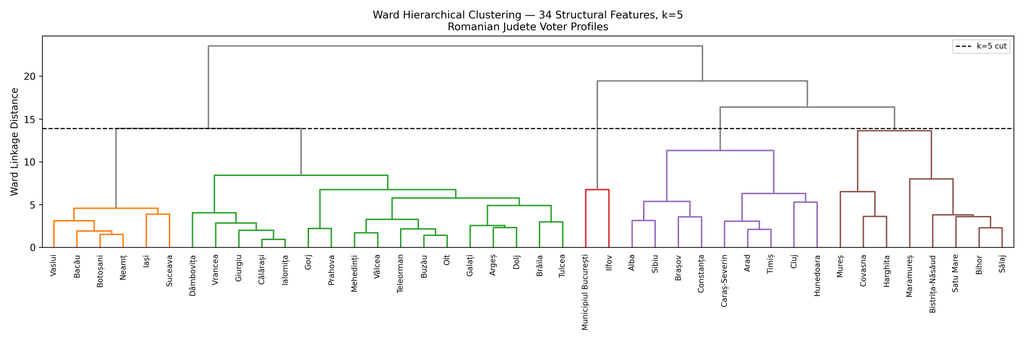

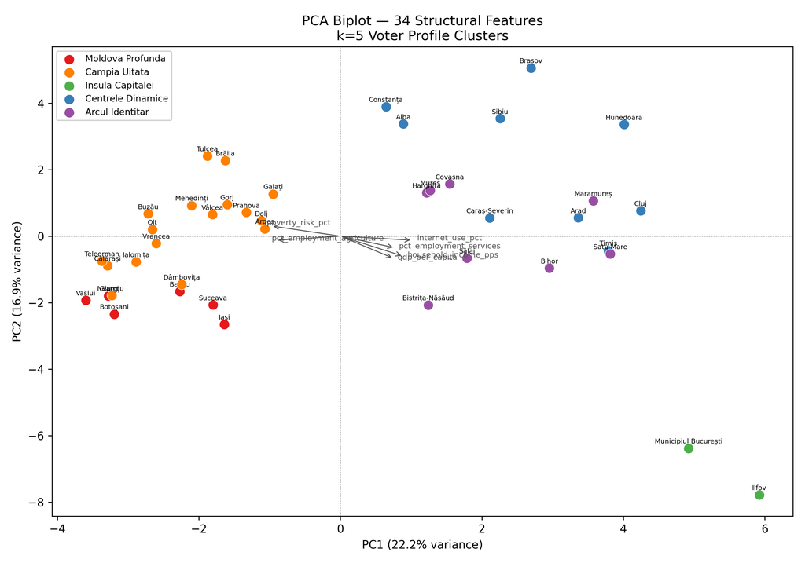

**C2 — Câmpia Uitată** (*n* = 17): The largest cluster, covering most of Wallachia and Dobrogea. Moderate GDP, lower deindustrialisation than expected (−0.47 SD) because energy and petrochemical rents have maintained a residual industry GVA share. The structural analogue to the Western European “left-behind” periphery (Rodríguez-Pose, 2018), but attenuated by sectoral rents.

**C3 — Insula Capitalei** (*n* = 2): București and Ilfov. An extreme outlier on GDP (+4.24 SD), household income (+3.98 SD), and urbanisation (+1.87 SD). Represents the capital-region concentration typical of Eastern European developmental states (Iammarino et al., 2019).

**C5 — Arcul Identitar** (*n* = 8): Bihor, Bistrița-Năsăud, Covasna, Harghita, Maramureș, Mureș, Satu Mare, Sălaj. Distinguished by ethnic diversity (Magyar-speaking minority, Reformed and Greco-Catholic denominations) and moderate deindustrialisation (+0.60 SD). The UDMR ethnic bloc vote is structurally encoded in this cluster.

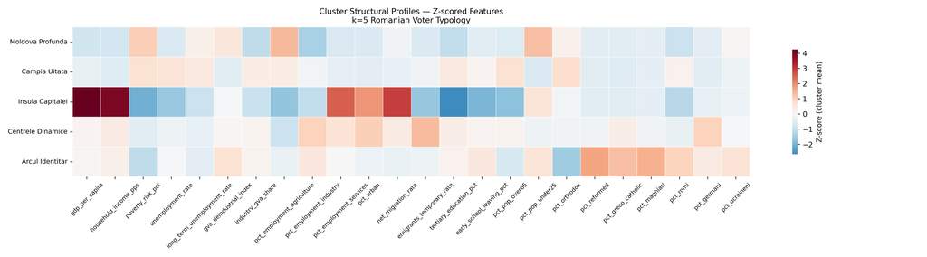

Z-scored cluster means on 24 key structural features. Red = above-average, blue = below-average.

## Cluster validation

One-way ANOVA on held-out electoral variables (not used in clustering) confirms significant between-cluster variation for all major parties (AUR: $F = 9.11$, $p < 0.001$; PSD: $F = 12.34$, $p < 0.001$; USR: $F = 13.96$, $p < 0.001$; UDMR: $F = 12.15$, $p < 0.001$). PNL is the sole exception ($F = 0.50$, $p = 0.74$), consistent with its cross-regional catch-all positioning.

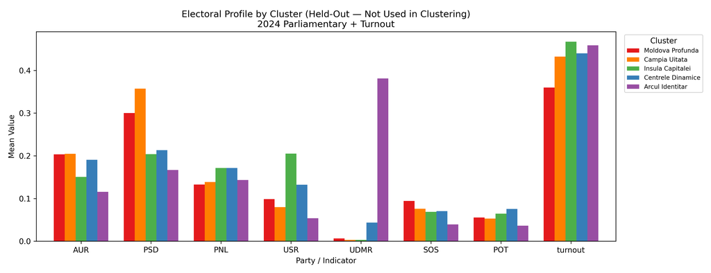

# Compositional Analysis of Vote Shares

## Dirichlet regression

Vote shares constitute compositional data: they are strictly positive, sum to one, and carry information only as ratios relative to each other (Aitchison, 1986; Pawlowsky-Glahn & Buccianti, 2011). Separate OLS regressions on each party violate the simplex constraint and ignore cross-party covariance. We instead model the joint composition $\mathbf{Y} = (y_1, \ldots, y_8)$ as a Dirichlet response:

$$\mathbf{Y} \sim \text{Dir}(\boldsymbol{\alpha}), \quad
\alpha_k = \mu_k \cdot \phi, \quad
\log\!\left(\frac{\mu_k}{\mu_K}\right) = \mathbf{x}^\top \boldsymbol{\beta}_k$$

where $\phi$ is a common precision parameter shared across categories (“common” parameterisation; Maier (2014)), $K = 8$ (*Other*) is the reference category, and $\mathbf{x}$ contains standardised structural predictors. Coefficients are on the additive log-ratio (ALR) scale: a positive $\hat{\beta}_k$ indicates that a one-SD increase in the predictor is associated with a higher share for party $k$ *relative to* the Other category.

We fit two nested models:

- **M1**: $\mathbf{Y} \sim$ grievance + modernity + % Magyar + deindustrialisation ($p = 4$, 40 parameters)
- **M2**: M1 + demographic pressure + % Roma + long-term unemployment ($p = 7$, 64 parameters)

Given $N = 42$, M1 represents the upper boundary of estimable model complexity for full standard-error recovery. M2 is included as a model-comparison benchmark via likelihood-ratio test; standard errors are unavailable due to Hessian non-convergence at this sample size.

Dirichlet regression model fit statistics. LR stat = $2(\ell_\text{full} - \ell_\text{null})$. Maddala $R^2 = 1 - \exp(-\text{LR}/N)$.

[output not shown]

## Coefficient results

M1 Dirichlet regression: significant predictors ($p < 0.10$), ordered by $p$-value. Coefficients on ALR scale (reference = Other). All predictors standardised.

Party

Predictor

$\hat{\beta}$

SE

$z$

$p$

Sig

UDMR

% Magyar

1.026

0.136

7.53

<0.001

***

POT

Deindustrialisation

0.543

0.165

3.30

<0.001

***

PSD

Deindustrialisation

0.348

0.128

2.73

0.006

USR

Deindustrialisation

0.336

0.138

2.44

0.015

OTHER

Deindustrialisation

0.311

0.128

2.43

0.015

UDMR

Modernity Index

0.675

0.293

2.30

0.021

SOS

Modernity Index

-0.326

0.148

-2.21

0.027

AUR

Deindustrialisation

0.285

0.131

2.17

0.030

PNL

Deindustrialisation

0.255

0.121

2.10

0.035

SOS

Deindustrialisation

0.278

0.133

2.09

0.037

PSD

Modernity Index

-0.249

0.123

-2.03

0.043

UDMR

Deindustrialisation

0.233

0.120

1.93

0.053

.

AUR

Modernity Index

-0.232

0.137

-1.70

0.089

.

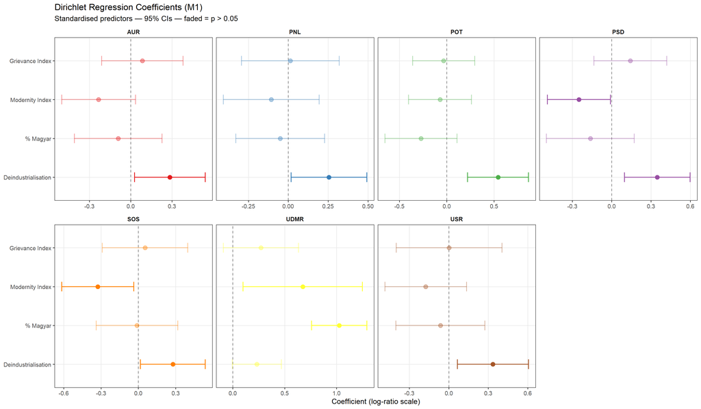

M1 Dirichlet regression coefficients with 95% confidence intervals. Coefficients on ALR scale relative to the Other category. Faded points: $p > 0.05$.

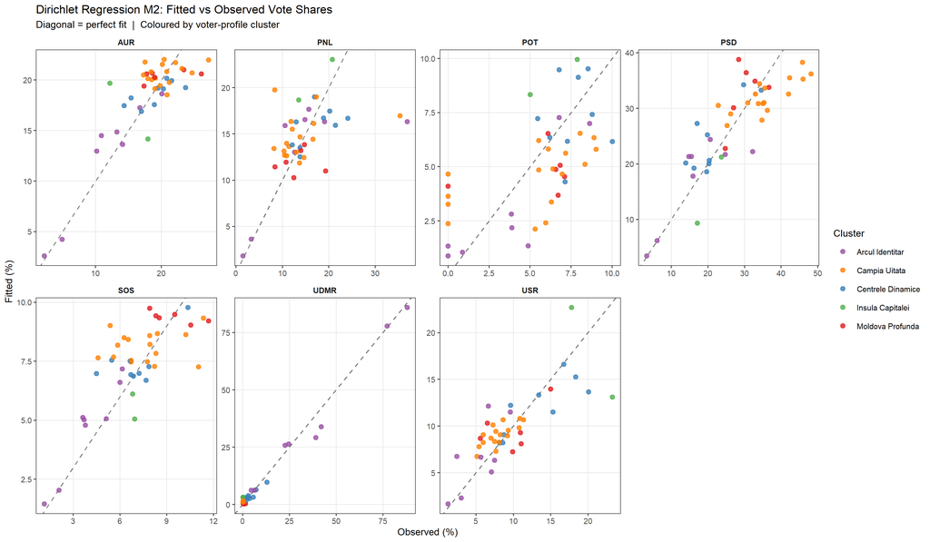

M2 fitted vs observed vote shares by party, coloured by voter-profile cluster. Diagonal = perfect calibration.

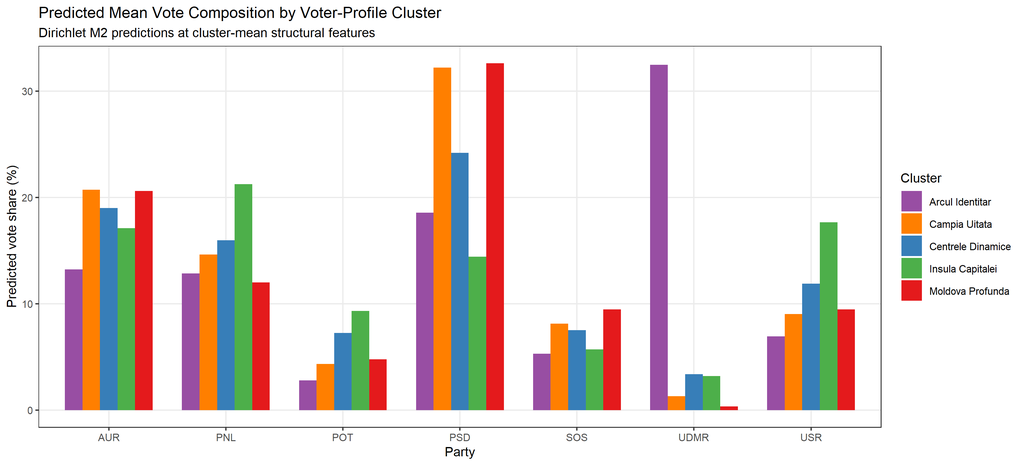

M2 predicted mean vote composition at cluster-mean structural values.

## Interpretation

Three patterns stand out.

*Modernity differentiates the remaining bloc.* Higher modernity is associated with lower SOS share ($\hat{\beta} = -0.326$, $p = 0.027$) and higher UDMR share ($\hat{\beta} = 0.675$, $p = 0.021$, reflecting UDMR’s urban concentration in Transylvanian cities). The grievance index, by contrast, has no significant net effect on any party’s share once structural predictors are controlled, suggesting that the spatial distribution of grievance does not map cleanly onto a single electoral outlet.

# The Georgescu–Simion Transfer

## Motivation and method

The November 2024 first-round presidential result for Călin Georgescu (annulled) and the May 2025 first-round result for George Simion provide a natural test of vote-bloc persistence across institutional discontinuity. A simple correlation would conflate genuine bloc cohesion with shared structural confounders: both candidates drew disproportionately from peripheral, deindustrialised counties.

We apply the Frisch-Waugh-Lovell (FWL) theorem (Frisch & Waugh, 1933; Lovell, 1963): residualise both the Georgescu vote share and the Simion vote share on the same set of structural controls, then compute the correlation of the two residual vectors. This partial correlation equals the OLS coefficient from a full regression of Simion on Georgescu conditional on all controls.

The control set comprises eight predictors with pairwise VIF $< 10$: grievance index, modernity index, demographic pressure index, agricultural employment share, Magyar share, Roma share, deindustrialisation index, and long-term unemployment rate. Composite indices (grievance, modernity, demographic pressure) absorb the collinear raw features while reducing the effective parameter count.

Standard errors on the partial correlation are obtained via a non-parametric bootstrap ($B = 10\,000$ draws with replacement). Sensitivity to unmeasured confounding is assessed using the Robustness Value framework of Cinelli & Hazlett (2020).

## Results

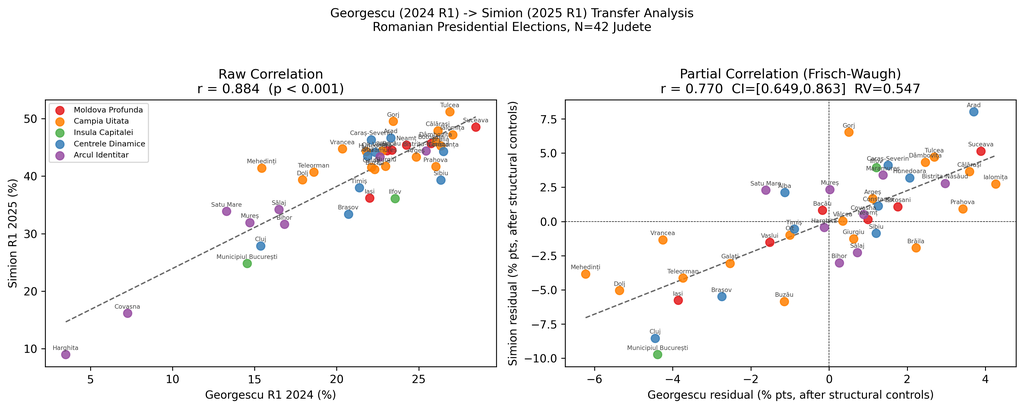

Partial correlation scatter plot: Simion 2025 R1 residuals vs Georgescu 2024 R1 residuals, after removing shared structural variance (8 controls). Points coloured by voter-profile cluster.

The raw county-level correlation between the two vote shares is $r = 0.884$ ($p < 0.001$). After removing shared structural variance, the partial correlation is $r_\text{partial} = 0.770$ (95% bootstrap CI: $[0.649, 0.863]$, $p < 0.0001$). The reduction from $r = 0.884$ to $r_\text{partial} = 0.770$ confirms that structural confounders explain part of the co-movement, but a substantial residual association remains.

Georgescu–Simion transfer: summary statistics.

| Statistic | Value |
| --- | --- |
| Raw correlation $r$ | 0.884 |
| Partial correlation $r_\text{p}$ | 0.770 |
| Bootstrap 95% CI | [0.649, 0.863] |
| $p$-value | <0.0001 |
| Robustness Value (RV) | 0.547 |

The Robustness Value $\text{RV} = 0.547$ indicates that an unmeasured confounder would need to explain at least 54.7% of the residual variance in *both* the Georgescu vote *and* the Simion vote (conditional on all eight included controls) to fully account for the partial correlation. This is a demanding threshold: for comparison, the strongest included control (deindustrialisation index) accounts for approximately 30% of the residual variance in each outcome. The finding is therefore robust to moderate omitted variable bias.

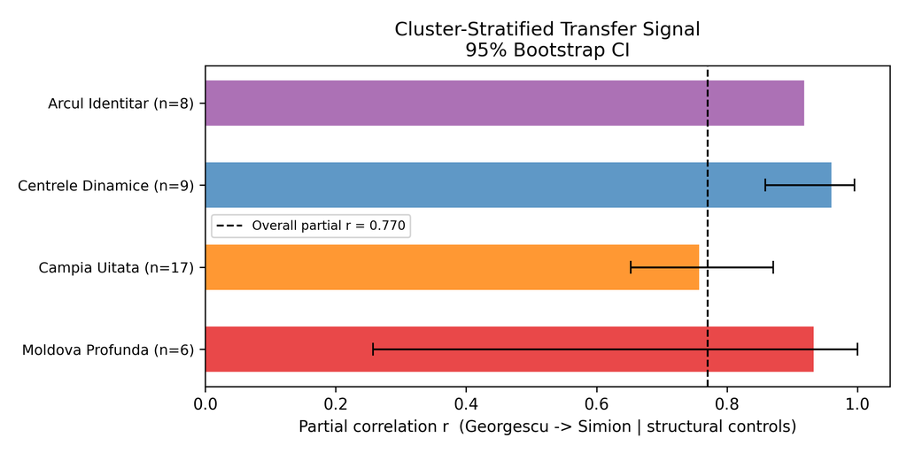

## Interpretation

The persistent partial correlation confirms the existence of a spatially stable nationalist-populist electoral bloc at the county level, whose cohesion is not reducible to the structural predictors included in the model. This is consistent with network-mobilisation theories of populist vote transfer (Mudde & Kaltwasser, 2017; Norris & Inglehart, 2019), in which social and online networks sustain bloc identity across candidate discontinuities.

The ecological nature of the data precludes individual-level inference (ecological fallacy caveat applies). The finding is best interpreted as evidence that *counties* that mobilised strongly for Georgescu subsequently mobilised strongly for Simion, net of structural conditions, rather than as evidence that individual Georgescu voters switched to Simion.

# Pending Analyses

*This section will be completed when additional data become available.*

## The Ghost Electorate (Task 5)

Using BEC registered voter rolls and INS adult-population estimates, we will construct a county-level *ghost electorate ratio*:

$$\text{GER}_i = \frac{V_{\text{registered},i} - P_{\text{adult},i}}{V_{\text{registered},i}}$$

Counties with high GER represent potential inflated roll denominators. We will test whether GER predicts turnout residuals after controlling for structural characteristics, following the methodology of Cantú & García-Ponce (2015) on electoral integrity.

## Temporal Comparison: 2020 vs 2024 Parliamentary Elections

When 2020 parliamentary results become available, we will extend the Dirichlet models to a two-period comparison and estimate swing vectors $\Delta \mathbf{Y}_i = \mathbf{Y}_{i,2024} - \mathbf{Y}_{i,2020}$ as a function of the deindustrialisation index and cluster membership, providing a difference-in-differences flavour to the structural argument.

# Discussion

## Structural geography and electoral fragmentation

The five-cluster typology reveals a Romanian electoral geography organised along two intersecting axes: a *development gradient* (Insula Capitalei → Centrele Dinamice → Câmpia Uitată → Moldova Profundă) and an *ethnic-confessional axis* (Arcul Identitar). The development gradient maps closely onto the spatial inequality literature on post-communist transition (Holesch & Kyriazi, 2022), while the ethnic axis reflects the persistence of communal identity as an electoral organiser (Enyedi, 2005).

## The limits of structural determinism

The Georgescu–Simion transfer analysis complicates a purely structural account. A partial correlation of 0.770 after controlling for eight structural predictors — with Robustness Value 0.547 — suggests that county-level bloc cohesion is not fully determined by observable socio-economic geography. The residual association could reflect: (a) unmeasured structural features (e.g., social capital deficits, media exposure); (b) network effects and social contagion operating below the county level; or (c) genuine ideological consistency among Georgescu/Simion voters that persists independent of material conditions. Distinguishing these mechanisms requires individual-level data that are not currently available.

# Conclusion

These findings contribute to the growing literature on structural drivers of populist voting in post-communist democracies and underscore that Romania’s 2024–2025 electoral fragmentation is not a temporary shock but the expression of durable spatial inequalities.

**Limitations.** All analyses are ecological: inferences about individual voters require survey data with spatial identifiers. The sample of 42 counties limits the power of Dirichlet regression and prevents the inclusion of rich cluster-fixed effects. The ghost electorate and local network analyses remain pending and may modify the structural conclusions once completed.

# References

Aitchison, J. (1986). *The statistical analysis of compositional data*. Chapman & Hall.

Bohle, D., & Greskovits, B. (2012). *Capitalist diversity on europe’s periphery*. Cornell University Press.

Cantú, F., & García-Ponce, O. (2015). Partisan losers’ effects: Perceptions of electoral integrity in mexico. *Electoral Studies*, *39*, 1–14. https://doi.org/10.1016/j.electstud.2015.03.004

Cinelli, C., & Hazlett, C. (2020). Making sense of sensitivity: Extending omitted variable bias. *Journal of the Royal Statistical Society: Series B*, *82*(1), 39–67. https://doi.org/10.1111/rssb.12348

Enyedi, Z. (2005). The role of agency in cleavage formation. *European Journal of Political Research*, *44*(5), 697–720. https://doi.org/10.1111/j.1475-6765.2005.00244.x

Frisch, R., & Waugh, F. V. (1933). Partial time regressions as compared with individual trends. *Econometrica*, *1*(4), 387–401. https://doi.org/10.2307/1907330

Hennig, C. (2007). Cluster-wise assessment of cluster stability. *Computational Statistics & Data Analysis*, *52*(1), 258–271. https://doi.org/10.1016/j.csda.2006.11.025

Holesch, A., & Kyriazi, A. (2022). Democratic backsliding in the european union: The role of the central and eastern european countries. *East European Politics*, *38*(1), 1–18. https://doi.org/10.1080/21599165.2021.1876428

Iammarino, S., Rodríguez-Pose, A., & Storper, M. (2019). Regional inequality in europe: Evidence, theory and policy implications. *Journal of Economic Geography*, *19*(2), 273–298. https://doi.org/10.1093/jeg/lby021

Lovell, M. C. (1963). Seasonal adjustment of economic time series and multiple regression analysis. *Journal of the American Statistical Association*, *58*(304), 993–1010. https://doi.org/10.1080/01621459.1963.10480682

Maier, M. J. (2014). *DirichletReg: Dirichlet regression for compositional data in R* (Research Report Series 125). Department of Statistics; Mathematics, WU Vienna. https://epub.wu.ac.at/4077/

Mudde, C., & Kaltwasser, C. R. (2017). *Populism: A very short introduction*. Oxford University Press.

Norris, P., & Inglehart, R. (2019). *Cultural backlash: Trump, brexit, and authoritarian populism*. Cambridge University Press. https://doi.org/10.1017/9781108595841

Nölke, A., & Vliegenthart, A. (2009). Enlarging the varieties of capitalism: The emergence of dependent market economies in east central europe. In *World Politics* (Vol. 61, pp. 670–702). https://doi.org/10.1017/S0043887109990098

Oesch, D. (2008). Explaining workers’ support for right-wing populist parties in western europe. *International Political Science Review*, *29*(3), 349–373. https://doi.org/10.1177/0192512107088390

Pawlowsky-Glahn, V., & Buccianti, A. (2011). *Compositional data analysis: Theory and applications*. Wiley.

Rodríguez-Pose, A. (2018). The revenge of the places that don’t matter (and what to do about it). *Cambridge Journal of Regions, Economy and Society*, *11*(1), 189–209. https://doi.org/10.1093/cjres/rsx024

Rooduijn, M., Kessel, S. van, Froio, C., Pirro, A., De Lange, S., Halikiopoulou, D., Lewis, P., Mudde, C., & Taggart, P. (2018). The PopuList: An overview of populist, far right, far left and eurosceptic parties in europe. *PopuList*. https://popu-list.org/

Tibshirani, R., Walther, G., & Hastie, T. (2001). Estimating the number of clusters in a data set via the gap statistic. *Journal of the Royal Statistical Society: Series B*, *63*(2), 411–423. https://doi.org/10.1111/1467-9868.00293

Ward, J. H. (1963). Hierarchical grouping to optimize an objective function. *Journal of the American Statistical Association*, *58*(301), 236–244. https://doi.org/10.1080/01621459.1963.10500845

# Appendix A — Data Sources and Coverage

Data sources and NUTS-3 coverage.

| Variable | Source | Dataset code | Coverage |
| --- | --- | --- | --- |
| GDP per capita | Eurostat | nama_10r_3gdp | 42/42 |
| Unemployment rate | Eurostat | lfst_r_lfu3rt | 42/42 |
| Long-term unemployment rate | Eurostat | lfst_r_lfu2ltu | 42/42 |
| Household income (PPS) | Eurostat | nama_10r_2hhinc | 42/42 |
| Industry GVA share | Eurostat | nama_10r_3gva | 42/42 |
| Deindustrialisation index | Derived (Eurostat GVA) | — | 42/42 |
| Ethnic composition | INS Census 2021 | RPL-2021 | 42/42 |
| Religious composition | INS Census 2021 | RPL-2021 | 42/42 |
| Electoral results | Autoritatea Electorală Permanentă | AEP 2024–25 | 42/42 |

# Appendix B — Cluster Compositions

County compositions of the $k=5$ voter-profile clusters.

| Cluster | n | Counties |
| --- | --- | --- |
| Moldova Profundă | 6 | Bacău, Botoșani, Iași, Neamț, Suceava, Vaslui |
| Câmpia Uitată | 17 | Argeș, Brăila, Buzău, Călărași, Dâmbovița, Dolj, Galați, Giurgiu, Gorj, Ialomița, Mehedinți, Olt, Prahova, Teleorman, Tulcea, Vâlcea, Vrancea |
| Insula Capitalei | 2 | București, Ilfov |
| Centrele Dinamice | 9 | Alba, Arad, Brașov, Caraș-Severin, Cluj, Constanța, Hunedoara, Sibiu, Timiș |
| Arcul Identitar | 8 | Bihor, Bistrița-Năsăud, Covasna, Harghita, Maramureș, Mureș, Satu Mare, Sălaj |

# Appendix C — Dirichlet Regression Full Coefficient Table (M1)

M1 Dirichlet regression: all non-intercept coefficients. ALR scale, reference = Other.

Party

Predictor

$\hat{\beta}$

SE

$z$

$p$

Sig

AUR

Grievance

0.085

0.151

0.56

0.574

—

AUR

Modernity

-0.232

0.137

-1.70

0.089

.

AUR

% Magyar

-0.090

0.162

-0.55

0.580

—

AUR

Deindustrial.

0.285

0.131

2.17

0.030

PSD

Grievance

0.143

0.142

1.01

0.313

—

PSD

Modernity

-0.249

0.123

-2.03

0.043

PSD

% Magyar

-0.162

0.171

-0.95

0.343

—

PSD

Deindustrial.

0.348

0.128

2.73

0.006

PNL

Grievance

0.013

0.156

0.08

0.935

—

PNL

Modernity

-0.107

0.154

-0.69

0.488

—

PNL

% Magyar

-0.051

0.142

-0.36

0.721

—

PNL

Deindustrial.

0.255

0.121

2.10

0.035

USR

Grievance

0.003

0.205

0.01

0.989

—

USR

Modernity

-0.175

0.158

-1.11

0.268

—

USR

% Magyar

-0.063

0.172

-0.37

0.713

—

USR

Deindustrial.

0.336

0.138

2.44

0.015

UDMR

Grievance

0.271

0.185

1.47

0.142

—

UDMR

Modernity

0.675

0.293

2.30

0.021

UDMR

% Magyar

1.026

0.136

7.53

<0.001

***

UDMR

Deindustrial.

0.233

0.120

1.93

0.053

.

SOS

Grievance

0.054

0.175

0.31

0.756

—

SOS

Modernity

-0.326

0.148

-2.21

0.027

SOS

% Magyar

-0.011

0.168

-0.07

0.948

—

SOS

Deindustrial.

0.278

0.133

2.09

0.037

POT

Grievance

-0.032

0.168

-0.19

0.848

—

POT

Modernity

-0.071

0.170

-0.42

0.677

—

POT

% Magyar

-0.272

0.195

-1.40

0.161

—

POT

Deindustrial.

0.543

0.165

3.30

<0.001

***

OTHER

Grievance

0.037

0.184

0.20

0.841

—

OTHER

Modernity

-0.245

0.151

-1.62

0.105

—

OTHER

% Magyar

0.002

0.162

0.01

0.993

—

OTHER

Deindustrial.

0.311

0.128

2.43

0.015